# Portfolio Part One: Airline Data

Morgan Eaton

2023-12-09

## Introduction

### Load the necessary libraries

```r
library(nycflights13)
library(tidyverse)
library(janitor)
library(here)
```

### Get data from the online source.

All the data used in this report is from week three on Moodle. The data can also be found in the Data Raw folder of the portfolio project. This is the airline data from 2017 to 2023.

### Load the BOT data

We take advantage of the here package to get the path to the file that we stored. Here I am looking at the data from 2022 to get an idea of what this dats is and how I can use it.

```r
thisfile=here("Data Raw", "AirplaneData","DL_SelectFields_2022.zip")

df2022=read_csv(thisfile) %>% clean_names()
```

## Initial Analysis - What Time of Year Might be Best?

### Subsetting to data of interest - Part One

Focusing on the flights from Bradley International Airport (BDL). Since this data set includes cargo flights and I want to look at passenger flights I am going to require that they flights have at least one passenger to eliminate carrgo flights.

Call the resultant dataframe ‘df9’.

```r
df9 = df2022 |> filter(passengers>0,origin=="BDL")
```

### Subsetting to data of interest - Part Two

At first I tried to visualize a monthly count of flights using a barchart.

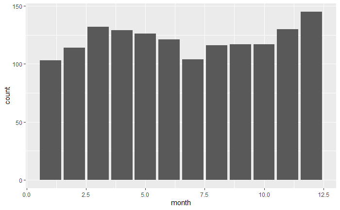

```r
df9 |>
  ggplot(aes(month)) + geom_bar()
```

However this visualization is not 100% correct since by default, ‘geom_bar’ is counting the number of rows, where we have asked it to visualize the count by ‘month’. Since the data set can have multiple flights listed in one row, counting the number of rows will not give us an accurate representation of how many flights happened each month.

Therefore the visualization I want is:

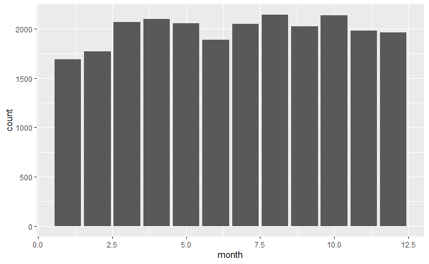

```r
df9 |> ggplot(aes(month)) + geom_bar(aes(weight=departures_performed))
```

### Number of Passengers

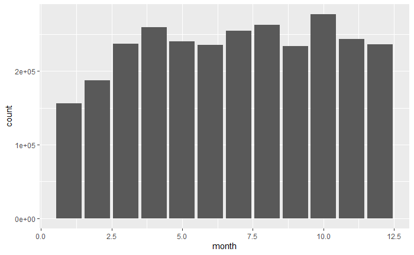

```r
df9 |> ggplot(aes(month)) + geom_bar(aes(weight=passengers))
```

### Arrivals and Departures from BDL

Since my grandparents will not only be flying out of BDL but they will have to fly into BDL to get home. So I wanted to look at the passenger counts for both in and out of BDL throughout the year.

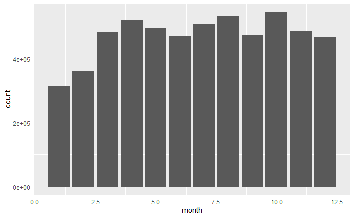

```r
df10 = df2022 |> filter(passengers>0,origin=="BDL" | dest=="BDL")

df10 |> ggplot(aes(month)) + geom_bar(aes(weight=passengers))
```

### Does the airpline type play a roll in this?

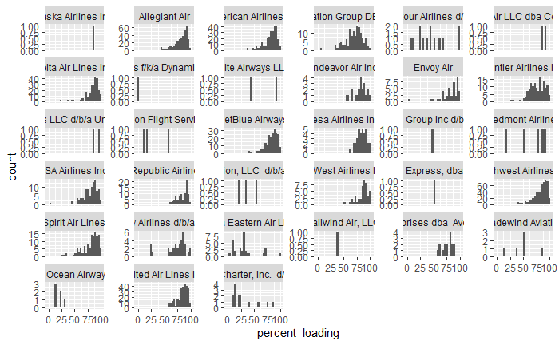

```r
df14 = df2022 |> filter(passengers>0,origin=="BDL" | dest=="SRQ")

df11=df14 |> select(month,passengers,seats,carrier_name,dest,origin)

df12 =df14 |> select(1:5, month,contains("id"))

df13 = df11 |> mutate(percent_loading = passengers/seats*100)

df13 |> ggplot(aes(percent_loading)) +
  geom_histogram()+facet_wrap(~carrier_name,scales="free_y")
```

Based on the visualization above there are some airlines that tend to load less than others. In order to stick with the common and trustworthy airlines, I’d suggest to them that they should stick with Breeze Aviation Group like they usually do.

## Looking at the data from 2017-2023

### Read in the rest of the data and assign it to a corresponding variable.

```r
#2017

thisfile=here("Data Raw", "AirplaneData","DL_SelectFields_2017.zip")

df2017=read_csv(thisfile) %>% clean_names()

#2018

thisfile=here("Data Raw", "AirplaneData","DL_SelectFields_2018.zip")

df2018=read_csv(thisfile) %>% clean_names()

#2019

thisfile=here("Data Raw", "AirplaneData","DL_SelectFields_2019.zip")

df2019=read_csv(thisfile) %>% clean_names()

#2020

thisfile=here("Data Raw", "AirplaneData","DL_SelectFields_2020.zip")

df2020=read_csv(thisfile) %>% clean_names()

#2021

thisfile=here("Data Raw","AirplaneData","DL_SelectFields_2021.zip")

df2021=read_csv(thisfile) %>% clean_names()

#2022

thisfile=here("Data Raw", "AirplaneData","DL_SelectFields_2022.zip")

df2022=read_csv(thisfile) %>% clean_names()

#2023

thisfile=here("Data Raw", "AirplaneData","DL_SelectFields_2023.zip")

df2023=read_csv(thisfile) %>% clean_names()
```

### Combine Dataframes into one

```r
dfc=
  bind_rows(df2017) |>
  bind_rows(df2018) |>
  bind_rows(df2019) |>
  bind_rows(df2020) |>
  bind_rows(df2021) |>
  bind_rows(df2022) |>
  bind_rows(df2023)
```

### Arrivals and Departures from BDL for all years

```r
dfc1=dfc |>
  filter(passengers>0,origin=="BDL" | dest =="BDL")
```

### Total Passengers by Month over Multiyear Period

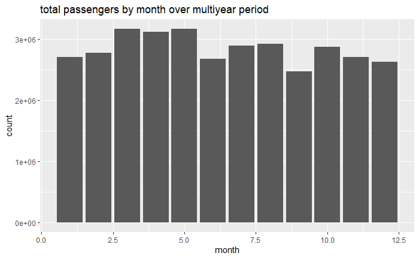

```r
dfc1 |> ggplot(aes(month)) +
  geom_bar(aes(weight=passengers)) +
  ggtitle("total passengers by month over multiyear period")
```

Based on this visualization January does not seem to be as low as before in terms of total passengers. Based on this graph the best time to fly would be September. This is a little early for them as they usually fly out in October but knowing flights might be better in September they might leave earlier. March-April is still a popular time for spring break and other holidays but they never travel at that time so I don’t think they will have to worry about that.

### Should this trend hold true?

Since factors like COVID can cause a big change in flights over time I wanted to see if there were any years that might effect the accuracy of the data.

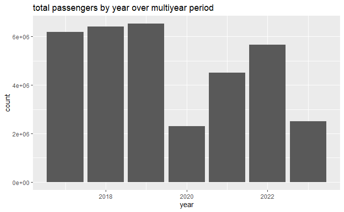

```r
dfc1 |> ggplot(aes(year)) +
  geom_bar(aes(weight=passengers)) +
  ggtitle("total passengers by year over multiyear period")
```

2020 does seem to have a much lower count compared to the other years which is most likely a result of COVID. This even seems to effect the number of passengers in later years as people slowly start using the airlines again.

### Give the passenger count over month levels for the entire period from 2017-2023

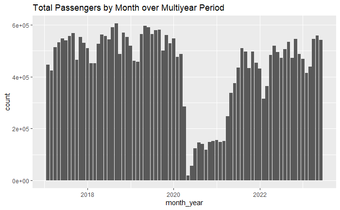

```r
dfc1|>
mutate(month_year = year+month/12) |>
  ggplot(aes(month_year)) +
    geom_bar(aes(weight=passengers))+
    ggtitle("Total Passengers by Month over Multiyear Period")
```

Based on this visualization the later 2022 and early 2023 seem to be picking up back to the normal levels before COVID.

## Conclusion

Based on my grandparents common travel plans of wanting to leave at some point in the fall and then return sometime in the new year I would recommend the following. I would recommend leaving in September instead of their usual October, and I would still return sometime in January or early February. In terms of which Airline might be best ( least number of people so they are comfortable) I’d suggest they stick with Breeze. That way there is roughly 75% off the plane full but the plane isn’t so empty they cancel the flight. I’d also warn them that it seems as though the COVID scare is going away so people are starting to fly more often so their flights (whether they like it or not) may start to get more crowded and the air travel industry is returning to normal.